## 🛠“Apoyo a la toma de decisiones basadas en evidencia

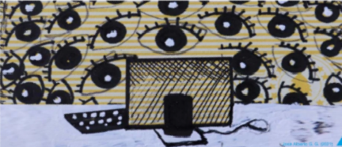

### Contextualización, identificación del problema, búsqueda de los datos, construcción de la muestra, análisis exploratorio de datos, modelización y presentación de los resultados

- 📊 El punto de partida  
  Contextualización del poblema: en donde estamos -> a donde queremos llegar
- 📊 Trabajando con Datos: creación de una Muestra Estratificada  
  Definición de la muestra a partir de las variables de interés
- Análisis descriptivo  
  Demos una mirada para ver que nos dicen los datos
- Modelo de regresión lineal  
  Hagamos inferencia con el Modelo lineal clásico (LMS)
- Modelo de regresión robusta  
  Una alternativa al Modelo lineal clásico (LMS) cuando los supuestos no se cumple
- Modelos de ensamble  
  Una alternativa al LMS a través de métodos de ensamble de machine learning (Ml) y redes neuronales (NN)
- Bosques de regresión  
  ¿Podemos mejorar la predicción del modelo - Aplicación de bosques de regresión
- Modelo de ensable: bagging y boosting  
  Vamos a mejorar la capacidad predictiva con Modelos de ensamble
- Modelo de redes neuronales nnet  
  Que nos dicen las redes neuronales: regresión utilizando nnet

Esta serie presenta un resumen de algunos variaciones de la regresión lineal para identificar el método óptimo a partir del modelo de la regresión lineal clásica